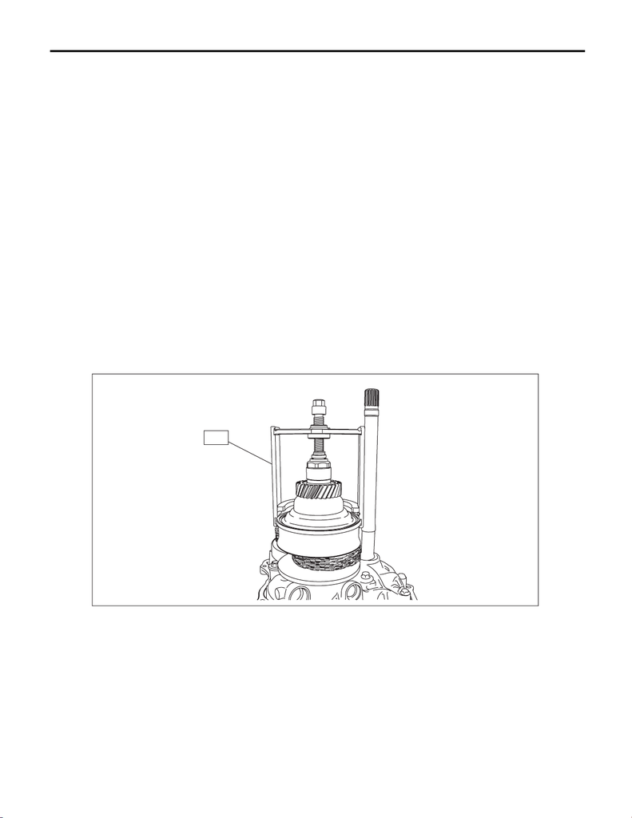

CVT(TR690)-228

Primary Pulley and Secondary Pulley

CONTINUOUSLY VARIABLE TRANSMISSION

41.Primary Pulley and Secondary Pulley

A: REMOVAL

NOTE:

Always replace primary pulley and secondary pulley as an assembly because they are non-disassembled

parts.

1) Remove the transmission assembly from the vehicle. <Ref. to CVT(TR690)-56, REMOVAL, Automatic

Transmission Assembly.>

2) Remove the air breather hose. <Ref. to CVT(TR690)-136, REMOVAL, Air Breather Hose.>

3) Remove the oil pan and control valve body. <Ref. to CVT(TR690)-112, REMOVAL, Control Valve Body.>

4) Remove the transmission harness. <Ref. to CVT(TR690)-123, REMOVAL, Transmission Harness.>

5) Remove the extension case. <Ref. to CVT(TR690)-142, REMOVAL, Extension Case.>

6) Remove the rear drive shaft. <Ref. to CVT(TR690)-146, REMOVAL, Rear Drive Shaft.>

7) Remove the transfer clutch assembly. <Ref. to CVT(TR690)-151, REMOVAL, Transfer Clutch.>

8) Remove the center differential carrier. <Ref. to CVT(TR690)-154, REMOVAL, Center Differential Carrier.>

9) Remove the transfer reduction driven gear assembly. <Ref. to CVT(TR690)-158, REMOVAL, Transfer Re-

duction Driven Gear.>

10) Remove the intermediate case. <Ref. to CVT(TR690)-165, REMOVAL, Intermediate Case.>

11) Remove the forward clutch assembly. <Ref. to CVT(TR690)-181, REMOVAL, Forward Clutch Assem-

bly.>

12) Remove the transmission case. <Ref. to CVT(TR690)-212, REMOVAL, Transmission Case.>

13) Set the ST to the secondary pulley, and expand the V groove of pulley until the variator chain gets com-

pletely loose.

ST 18769AA000 EXPANDER PULLEY

AT-05296

ST

15WRX_STI_US_EN.book 228 ページ ２０１５年２月１３日 金曜日 午前１１時２０分

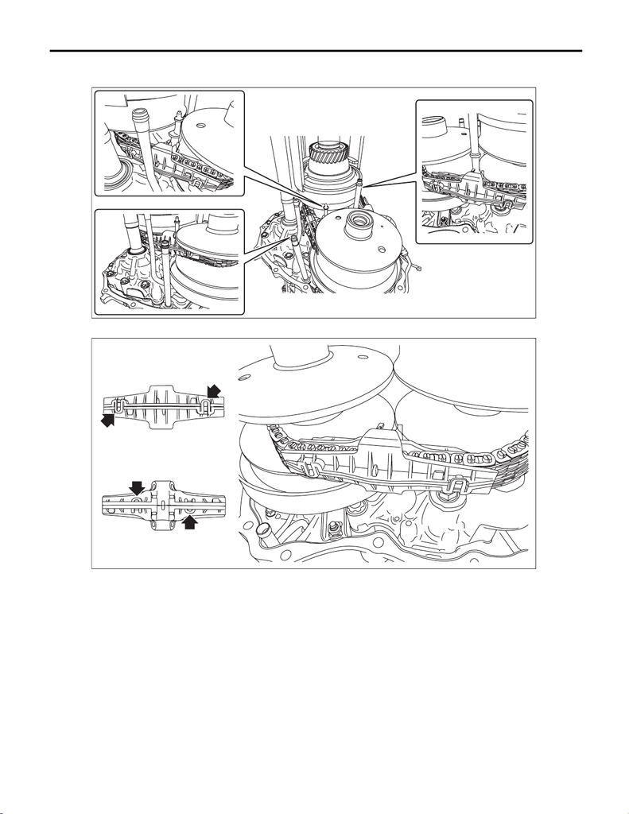

CVT(TR690)-229

Primary Pulley and Secondary Pulley

CONTINUOUSLY VARIABLE TRANSMISSION

14) Remove the chain guide from lubrication pipe and support rod.

15) Remove the lubrication pipe and support rod.

16) Detach the four claws to remove the two chain guides.

AT-07371

AT-07372

15WRX_STI_US_EN.book 229 ページ ２０１５年２月１３日 金曜日 午前１１時２０分

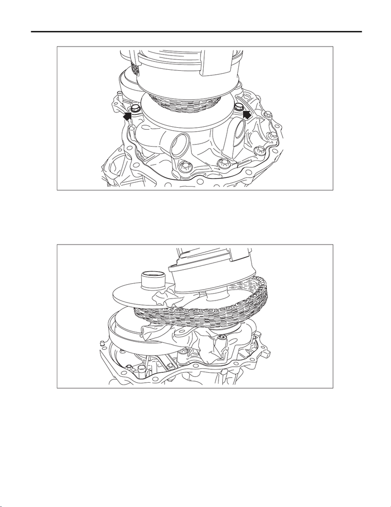

CVT(TR690)-230

Primary Pulley and Secondary Pulley

CONTINUOUSLY VARIABLE TRANSMISSION

17) Remove the secondary pulley mounting bolt.

18) Remove the secondary pulley from drive pinion retainer and intersect the V groove of secondary pulley

and V groove of primary pulley. Remove the variator chain from secondary pulley and remove the secondary

pulley.

CAUTION:

Cover the V grooves of secondary pulley and primary pulley with cloth to protect the both pulleys

and variator chain from scratching.

AT-06557

AT-05300

15WRX_STI_US_EN.book 230 ページ ２０１５年２月１３日 金曜日 午前１１時２０分

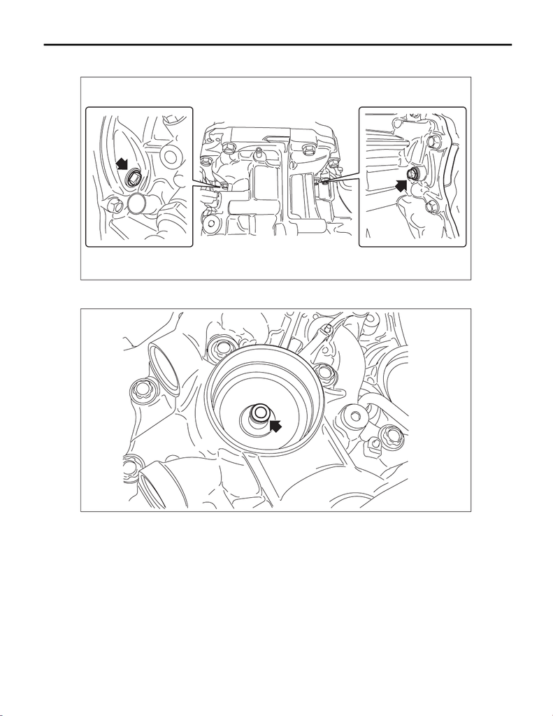

CVT(TR690)-231

Primary Pulley and Secondary Pulley

CONTINUOUSLY VARIABLE TRANSMISSION

19) Remove the variator chain from primary pulley.

20) Remove the primary pulley mounting bolt.

21) Remove the primary pulley.

22) Remove the two seal rings from drive pinion retainer.

AT-05301

AT-05302

15WRX_STI_US_EN.book 231 ページ ２０１５年２月１３日 金曜日 午前１１時２０分

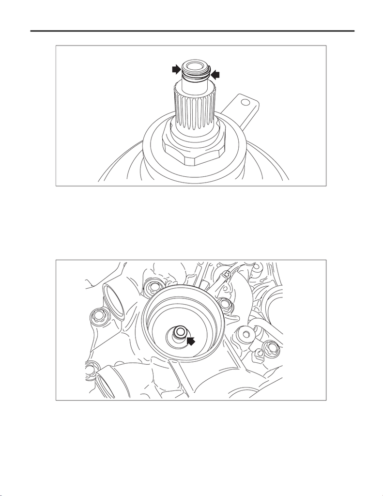

CVT(TR690)-232

Primary Pulley and Secondary Pulley

CONTINUOUSLY VARIABLE TRANSMISSION

23) Remove the two seal rings from primary pulley.

B: INSTALLATION

1) Select shims for pulley alignment. <Ref. to CVT(TR690)-238, ADJUSTMENT, Primary Pulley and Second-

ary Pulley.>

2) Install the two seal rings to drive pinion retainer.

NOTE:

• Use new seal rings.

• Apply CVTF to the seal rings.

• When installing the seal rings, do not expand the seal rings too much.

AT-05493

AT-05302

15WRX_STI_US_EN.book 232 ページ ２０１５年２月１３日 金曜日 午前１１時２０分

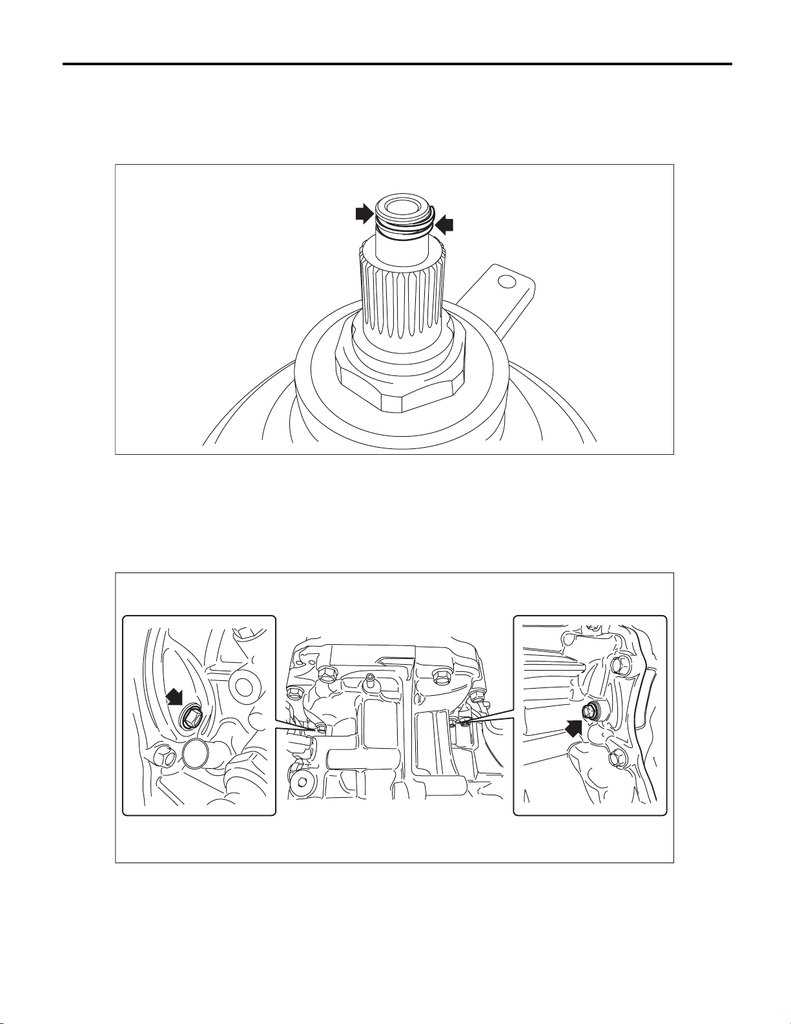

CVT(TR690)-233

Primary Pulley and Secondary Pulley

CONTINUOUSLY VARIABLE TRANSMISSION

3) Install the selected shims to the primary pulley bearing catch surface.

4) Install the two seal rings to primary pulley.

NOTE:

• Use new seal rings.

• Apply CVTF to the seal rings.

5) Install the primary pulley and adjust the position of bolt holes of primary bearing retainer and converter

case to tighten the primary pulley bolt.

NOTE:

Use a new seal washer.

Tightening torque:

21 N·m (2.1 kgf-m, 15.5 ft-lb)

AT-05493

AT-05301

15WRX_STI_US_EN.book 233 ページ ２０１５年２月１３日 金曜日 午前１１時２０分

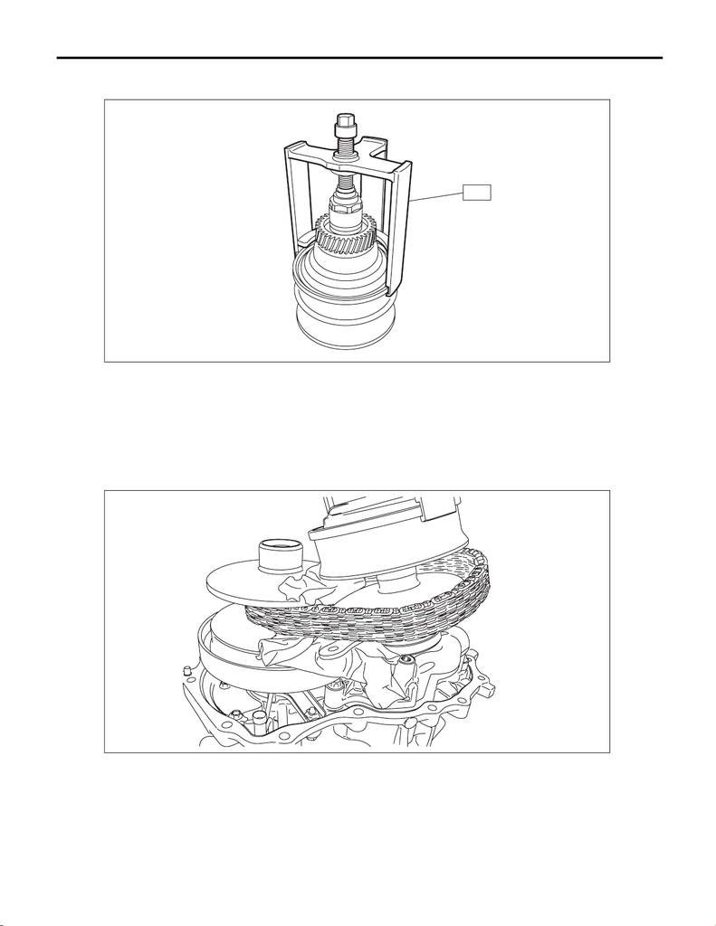

CVT(TR690)-234

Primary Pulley and Secondary Pulley

CONTINUOUSLY VARIABLE TRANSMISSION

6) Set the ST to secondary pulley and expand the V groove of pulley.

ST 18769AA000 EXPANDER PULLEY

7) Place the variator chain on the primary pulley groove and attach the secondary pulley and variator chain

together to the drive pinion retainer.

CAUTION:

Cover the V grooves of primary pulley and secondary pulley with cloth to protect the both pulleys

and variator chain from scratching.

(1) Place the variator chain on primary pulley.

(2) Intersect the V groove of primary pulley and the V groove of secondary pulley and install the second-

ary pulley while placing the variator chain on secondary pulley.

(3) While aligning the bolt hole of secondary bearing retainer and the bolt hole of driving pinion retainer,

install the secondary pulley to drive pinion retainer.

AT-05303

ST

AT-05300

15WRX_STI_US_EN.book 234 ページ ２０１５年２月１３日 金曜日 午前１１時２０分

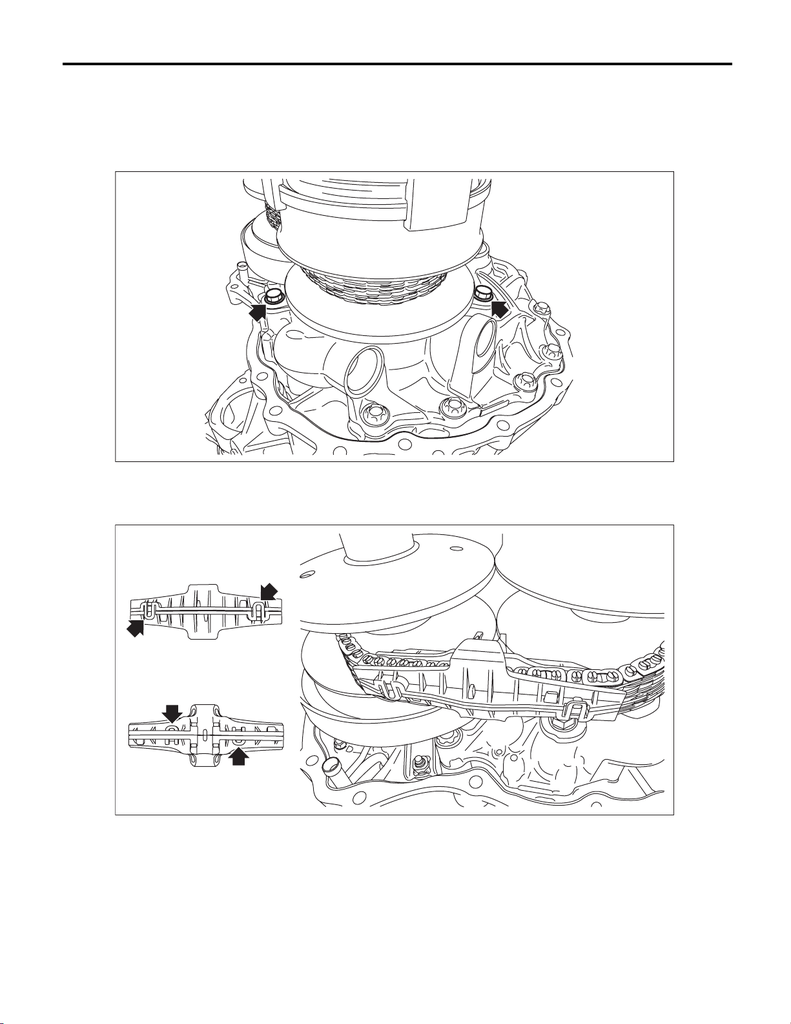

CVT(TR690)-235

Primary Pulley and Secondary Pulley

CONTINUOUSLY VARIABLE TRANSMISSION

8) Install the secondary pulley bolt.

NOTE:

Apply CVTF to the bolt.

Tightening torque:

33 N·m (3.4 kgf-m, 24.3 ft-lb)

9) Install the chain guide.

NOTE:

Install it with two claws facing outward and with two claws facing inward.

AT-06557

AT-07372

15WRX_STI_US_EN.book 235 ページ ２０１５年２月１３日 金曜日 午前１１時２０分

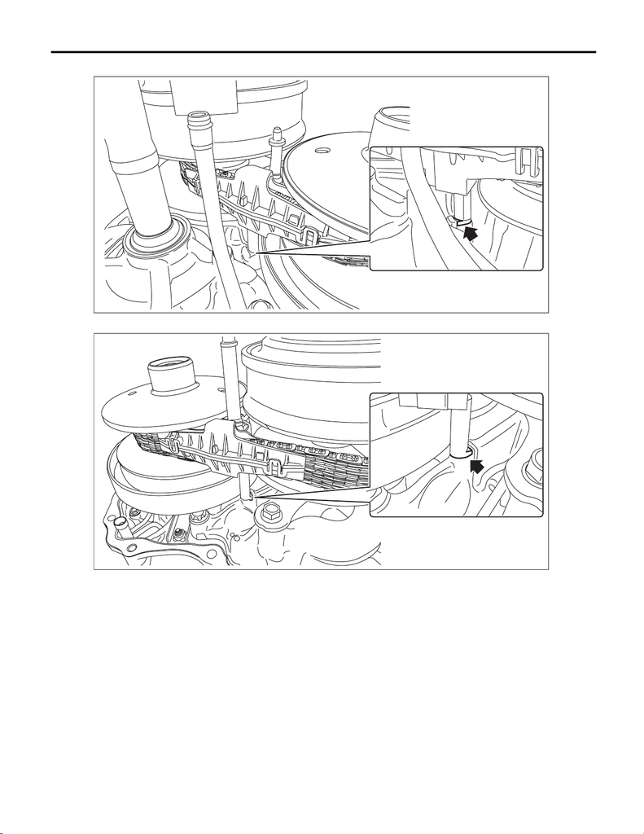

CVT(TR690)-236

Primary Pulley and Secondary Pulley

CONTINUOUSLY VARIABLE TRANSMISSION

10) Engage the cutout portions of support rod and drive pinion retainer and install the support rod.

11) Engage the cutout portions of lubrication pipe and drive pinion retainer and install the lubrication pipe.

AT-07373

AT-07374

15WRX_STI_US_EN.book 236 ページ ２０１５年２月１３日 金曜日 午前１１時２０分

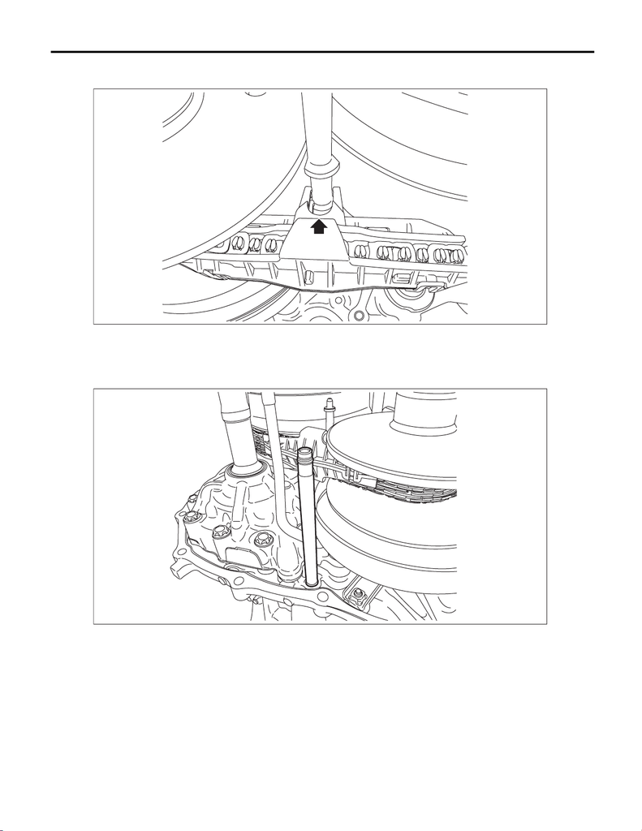

CVT(TR690)-237

Primary Pulley and Secondary Pulley

CONTINUOUSLY VARIABLE TRANSMISSION

12) Install the chain guide so that the lubrication pipe and support rod run through between the protrusions

of each chain guide. Then remove the ST (EXPANDER PULLEY).

13) Install the O-ring to the lubrication pipe.

NOTE:

Use new O-rings.

14) Install the lubrication pipe.

AT-07375

AT-07376

15WRX_STI_US_EN.book 237 ページ ２０１５年２月１３日 金曜日 午前１１時２０分

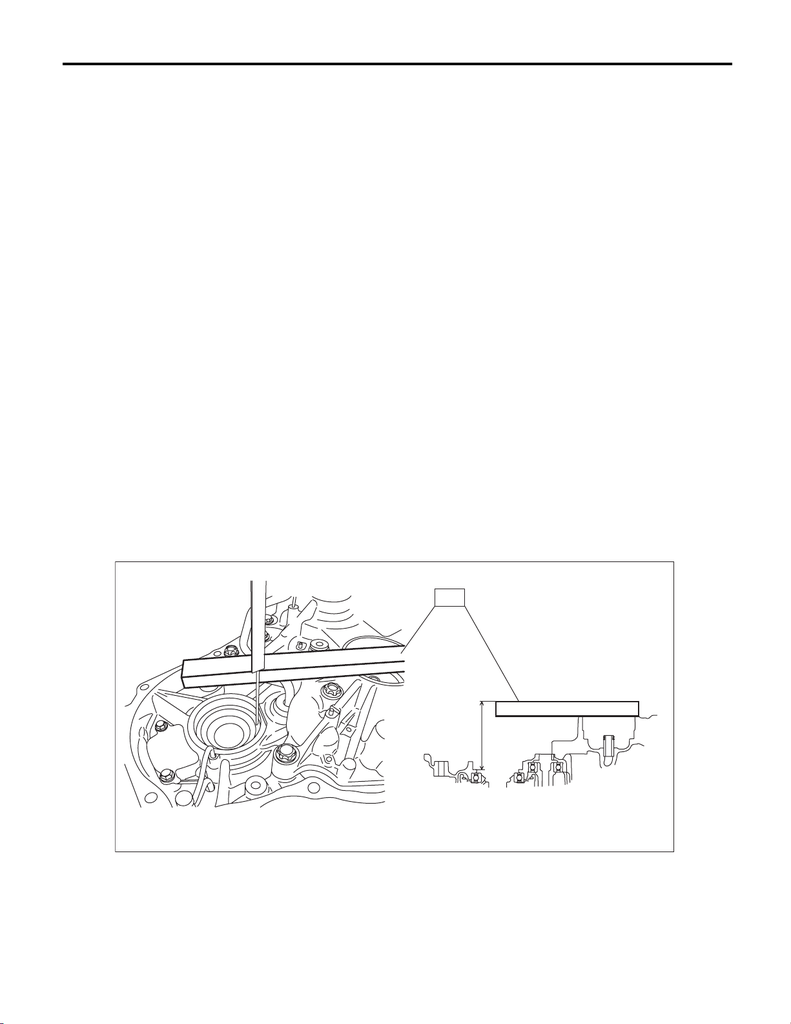

CVT(TR690)-238

Primary Pulley and Secondary Pulley

CONTINUOUSLY VARIABLE TRANSMISSION

15) Install the transmission case. <Ref. to CVT(TR690)-214, INSTALLATION, Transmission Case.>

16) Install the forward clutch assembly. <Ref. to CVT(TR690)-182, INSTALLATION, Forward Clutch Assem-

bly.>

17) Install the intermediate case. <Ref. to CVT(TR690)-166, INSTALLATION, Intermediate Case.>

18) Install the transfer reduction driven gear assembly. <Ref. to CVT(TR690)-158, INSTALLATION, Transfer

Reduction Driven Gear.>

19) Install the center differential carrier. <Ref. to CVT(TR690)-155, INSTALLATION, Center Differential Car-

rier.>

20) Install the transfer clutch assembly. <Ref. to CVT(TR690)-151, INSTALLATION, Transfer Clutch.>

21) Install the rear drive shaft. <Ref. to CVT(TR690)-146, INSTALLATION, Rear Drive Shaft.>

22) Install the extension case. <Ref. to CVT(TR690)-143, INSTALLATION, Extension Case.>

23) Install the transmission harness. <Ref. to CVT(TR690)-125, INSTALLATION, Transmission Harness.>

24) Install the control valve body and oil pan. <Ref. to CVT(TR690)-116, INSTALLATION, Control Valve

Body.>

25) Install the air breather hose. <Ref. to CVT(TR690)-136, INSTALLATION, Air Breather Hose.>

26) Install the transmission assembly to the vehicle. <Ref. to CVT(TR690)-69, INSTALLATION, Automatic

Transmission Assembly.>

C: INSPECTION

• Check the surface of primary and secondary pulley cones for damage or wear.

• Check the primary and secondary pulley for damage.

• Check the bearing for seizure or wear.

• Apply CVTF to bearing and rotate the bearing to check for noise or dragging etc.

D: ADJUSTMENT

1. PROCEDURE IN REPLACEMENT OF PRIMARY AND SECONDARY PULLEY, OR IN RE-

PLACEMENT OF PRIMARY PULLEY, SECONDARY PULLEY AND VARIATOR CHAIN

1) Measure depth “Lp” from the ST upper face to the primary pulley bearing catch surface at several points

and calculate the average.

ST 499575400 GAUGE

AT-07892

Lp

ST

15WRX_STI_US_EN.book 238 ページ ２０１５年２月１３日 金曜日 午前１１時２０分

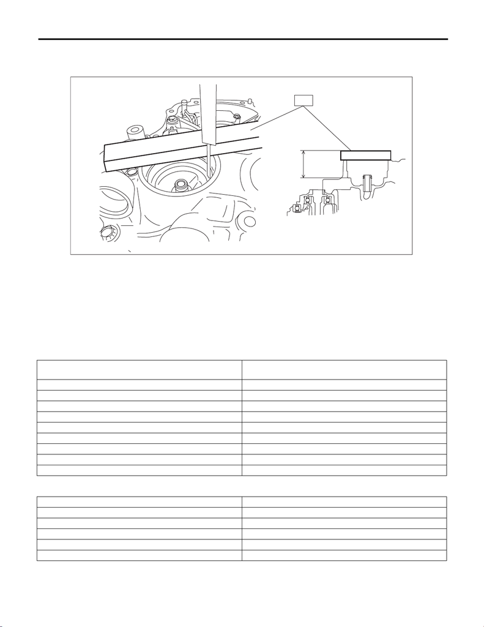

CVT(TR690)-239

Primary Pulley and Secondary Pulley

CONTINUOUSLY VARIABLE TRANSMISSION

ST 499575400 GAUGE

3) Calculate the following formula.

Calculation formula:

T (mm) = B + (Lp – Ls ) + 31.601 – A

T: Pulley alignment

A: Specified primary pulley dimension

B: Specified secondary pulley dimension

Lp: Depth from the ST upper face to the primary pulley bearing catch surface

Ls: Depth from the ST upper face to the secondary pulley bearing catch surface

4) Select one to two shims so that the total thickness meets the value obtained from step 3).

Pulley alignment

T mm (in)

Shim thickness mm (in)

0.050 — 0.150 (0.002 — 0.006) 0.1 (0.004)

0.151 — 0.250 (0.006 — 0.01) 0.2 (0.008)

0.251 — 0.350 (0.01 — 0.014) 0.3 (0.012)

0.351 — 0.450 (0.014 — 0.018) 0.4 (0.016)

0.451 — 0.550 (0.018 — 0.022) 0.5 (0.020)

0.551 — 0.650 (0.022 — 0.026) 0.6 (0.024)

0.651 — 0.750 (0.026 — 0.030) 0.7 (0.028)

0.751 — 0.850 (0.030 — 0.033) 0.8 (0.031)

0.851 — 0.950 (0.033 — 0.037) 0.9 (0.035)

Part No. Shim thickness mm (in)

32451AA000 0.1 (0.004)

32451AA010 0.2 (0.008)

32451AA020 0.3 (0.012)

32451AA030 0.4 (0.016)

32451AA040 0.5 (0.020)

AT-07895

Ls

ST

15WRX_STI_US_EN.book 239 ページ ２０１５年２月１３日 金曜日 午前１１時２０分

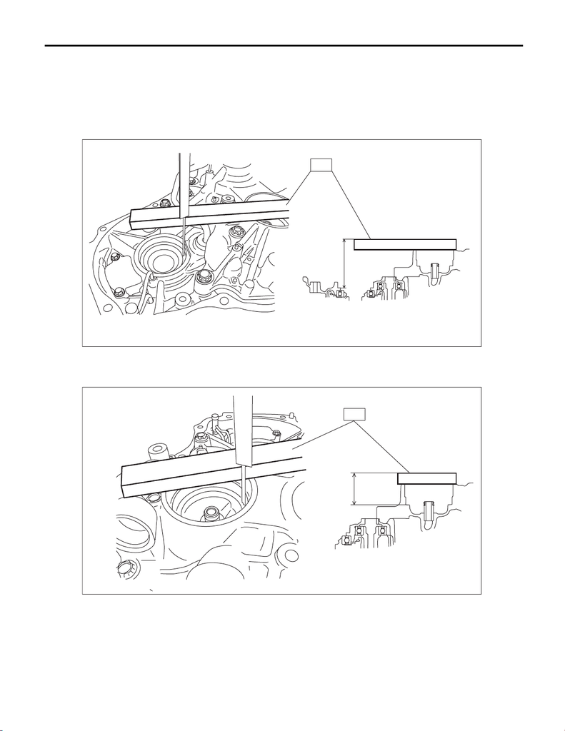

CVT(TR690)-240

Primary Pulley and Secondary Pulley

CONTINUOUSLY VARIABLE TRANSMISSION

2. PROCEDURE WHEN REPLACING ONLY DRIVE PINION RETAINER OR CONVERTER

CASE

1) Clean the mating surface of current drive pinion retainer and converter case.

2) Measure and record the shim thickness that is attached on the current converter case.

3) Using the current drive pinion retainer, measure depth “Lp1” from the ST upper face to the primary pulley

bearing catch surface at several points and calculate the average.

ST 499575400 GAUGE

4) Using the current drive pinion retainer or current converter case, measure depth “Ls1” from the ST upper

face to the secondary pulley bearing catch surface at several points and calculate the average.

ST 499575400 GAUGE

5) Calculate the “LD1” using the following formula and record it.

Calculation formula:

LD1 mm (in) = Lp1 – Ls1

LD1: Height from the primary pulley bearing catch surface to the secondary pulley bearing catch surface

Lp1: Depth from the ST upper face to the primary pulley bearing catch surface

Ls1: Depth from the ST upper face to the secondary pulley bearing catch surface

AT-07896

Lp1

ST

AT-07897

Ls1

ST

15WRX_STI_US_EN.book 240 ページ ２０１５年２月１３日 金曜日 午前１１時２０分

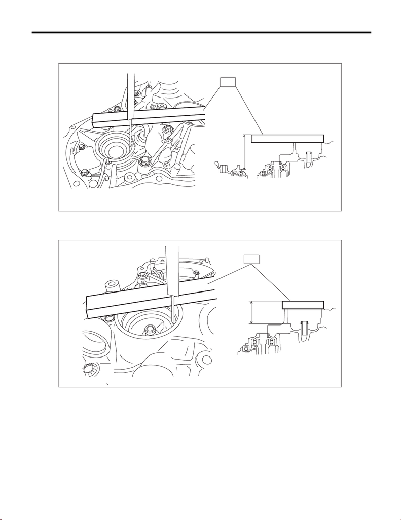

CVT(TR690)-241

Primary Pulley and Secondary Pulley

CONTINUOUSLY VARIABLE TRANSMISSION

6) Using the new drive pinion retainer or new converter case, measure depth “Lp2” from the ST upper face

to the primary pulley bearing catch surface at several points and calculate the average.

ST 499575400 GAUGE

7) Using the new drive pinion retainer or new converter case, measure depth “Ls2” from the ST upper face

to the secondary pulley bearing catch surface at several points and calculate the average.

ST 499575400 GAUGE

8) Calculate the “LD2” using the following formula and record it.

Calculation formula:

LD2 mm (in) = Lp2 – Ls2

LD2: Height from the primary pulley bearing catch surface to the secondary pulley bearing catch surface

Lp2: Depth from the ST upper face to the primary pulley bearing catch surface

Ls2: Depth from the ST upper face to the secondary pulley bearing catch surface

AT-07898

Lp2

ST

AT-07899

Ls2

ST

15WRX_STI_US_EN.book 241 ページ ２０１５年２月１３日 金曜日 午前１１時２０分

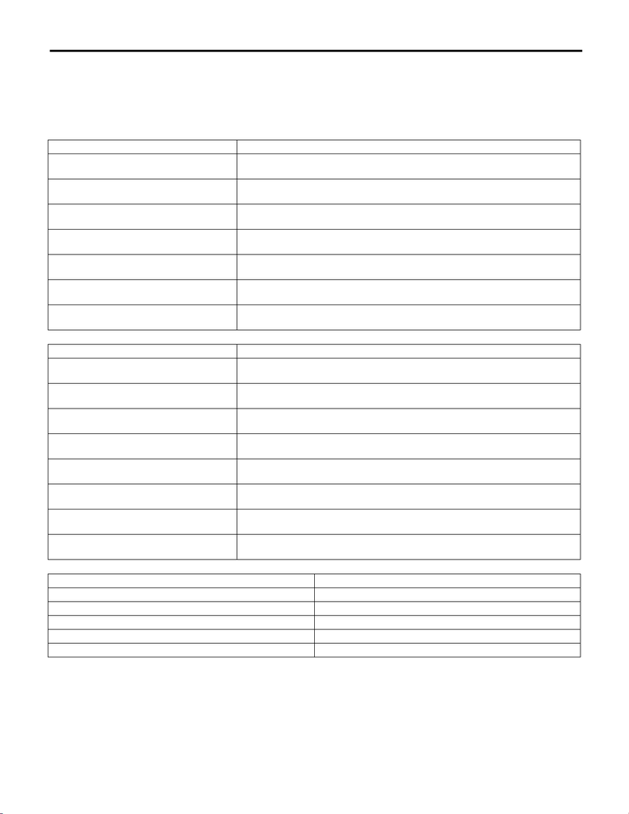

CVT(TR690)-242

Primary Pulley and Secondary Pulley

CONTINUOUSLY VARIABLE TRANSMISSION

9) Calculate the recorded values of “LD1” and “LD2” to obtain the positive number to select the shims.

Calculation formula: T1 mm (in) = LD1 – LD2 or T2 mm (in) = LD2 – LD1

T1, T2: Difference between new drive pinion retainer or new converter case and current drive pinion retainer

or current converter case

LD1: Calculated value of current drive pinion retainer or current converter case

LD2: Calculated value of new drive pinion retainer or new converter case

Difference of the case (T1) mm (in) Shim selection procedure

0 — 0.020 (0 — 0.00078) Select new shim of same thickness with the shim that is used on primary pulley

side of the current converter case.

0.021 — 0.070 (0.000827 — 0.00275) Select new shim of same thickness with the shim that is used on primary pulley

side of the current converter case.

0.071 — 0.125 (0.00279 — 0.00492) Select the shim 0.1 mm thinner than the shim that is used on primary pulley side of

the current converter case.

0.126 — 0.170 (0.00496 — 0.00669) Select the shim 0.1 mm thinner than the shim that is used on primary pulley side of

the current converter case.

0.171 — 0.230 (0.00673 — 0.00905) Select the shim 0.2 mm thinner than the shim that is used on primary pulley side of

the current converter case.

0.251 — 0.300 (0.00988 — 0.01181) Select the shim 0.3 mm thinner than the shim that is used on primary pulley side of

the current converter case.

Difference of the case (T2) mm (in) Shim selection procedure

0 — 0.020 (0 — 0.00078) Select new shim of same thickness with the shim that is used on primary pulley

side of the current converter case.

0.021 — 0.080 (0.000827 — 0.00315) Select new shim of same thickness with the shim that is used on primary pulley

side of the current converter case.

0.081 — 0.100 (0.00318 — 0.00393) Select the shim 0.1 mm thicker than the shim that is used on primary pulley side of

the current converter case.

0.101 — 0.120 (0.00397 — 0.00472) Select the shim 0.1 mm thicker than the shim that is used on primary pulley side of

the current converter case.

0.121 — 0.180 (0.00476 — 0.00708) Select the shim 0.1 mm thicker than the shim that is used on primary pulley side of

the current converter case.

0.181 — 0.220 (0.00712 — 0.00866) Select the shim 0.2 mm thicker than the shim that is used on primary pulley side of

the current converter case.

0.221 — 0.280 (0.00870 — 0.01102) Select the shim 0.2 mm thicker than the shim that is used on primary pulley side of

the current converter case.

0.281 — 0.300 (0.01106 — 0.01181) Select the shim 0.3 mm thicker than the shim that is used on primary pulley side of

the current converter case.

Part No. Shim thickness mm (in)

32451AA000 0.1 (0.004)

32451AA010 0.2 (0.008)

32451AA020 0.3 (0.012)

32451AA030 0.4 (0.016)

32451AA040 0.5 (0.020)

15WRX_STI_US_EN.book 242 ページ ２０１５年２月１３日 金曜日 午前１１時２０分